# MaxDiff and Conjoint Analysis: A Combined Learning Module

Market Research Team

2025-04-23

# 1. Introduction

## What are Conjoint and MaxDiff analyses?

Conjoint analysis and Maximum Difference Scaling (MaxDiff) are powerful market research techniques to understand consumer preferences.

**Conjoint Analysis** measures trade-offs among product features, simulating real-world purchasing decisions (e.g., price vs. quality).

**MaxDiff Analysis** (Best-Worst Scaling) measures the relative importance of items by asking respondents to select the most and least important items from subsets.

## When to use which method?

| Aspect | Conjoint Analysis | MaxDiff Analysis |
| --- | --- | --- |
| **Primary Use** | Trade-offs between attributes | Prioritizing features |
| **Best For** | Product configuration, pricing | Feature prioritization, messaging |
| **Decision Context** | Multi-attribute decisions | Relative importance |
| **Output** | Part-worth utilities, market simulations | Preference scores, rankings |
| **Sample Size** | Moderate to large | Smaller samples viable |

## Key differences

- **Conjoint Analysis**: Evaluates complete product profiles with multiple attributes.
- **MaxDiff Analysis**: Assesses individual items in isolation.

**Choose Conjoint** for trade-off analysis and market simulations.  
**Choose MaxDiff** for prioritizing features or benefits without trade-offs.

# 2. Study Design

## How to design a Conjoint experiment

### Attributes and levels selection

```r
# Define attributes and levels
smartphone_attrs <- list(
  brand = c("Apple", "Samsung", "Google", "Xiaomi"),
  price = c("$400", "$700", "$1000"),
  battery = c("15 hours", "20 hours", "25 hours"),
  camera = c("16 MP", "64 MP", "128 MP")
)

# Display attributes
for (attr in names(smartphone_attrs)) {
  cat(sprintf("Attribute: %s\nLevels: %s\n\n", attr, paste(smartphone_attrs[[attr]], collapse = ", ")))
}
```

```
## Attribute: brand
## Levels: Apple, Samsung, Google, Xiaomi
##
## Attribute: price
## Levels: $400, $700, $1000
##
## Attribute: battery
## Levels: 15 hours, 20 hours, 25 hours
##
## Attribute: camera
## Levels: 16 MP, 64 MP, 128 MP
```

**Tips for Attributes**: - Choose 4-6 relevant attributes. - Select realistic, distinct levels. - Avoid respondent fatigue.

### Types of conjoint designs

1. **Full-profile**: Evaluate all attributes.
2. **Choice-based (CBC)**: Choose between profiles.
3. **Adaptive**: Adjusts based on responses.

### Experimental design considerations

- **Orthogonality**: Independent attribute variation.
- **Balance**: Equal level appearances.
- **Efficiency**: Maximize information, minimize burden.

```r
# Create full factorial design
full_factorial <- expand.grid(smartphone_attrs)

# Generate efficient design
n_profiles <- 16
if (nrow(full_factorial) < n_profiles) {
  stop("Requested profiles exceed possible combinations")
}
design <- optFederov(
  ~ brand + price + battery + camera,
  data = full_factorial,
  nTrials = n_profiles,
  approximate = TRUE
)

knitr::kable(head(design$design), caption = "Sample Conjoint Design")
```

Sample Conjoint Design

|  | Rep.. | brand | price | battery | camera |
| --- | --- | --- | --- | --- | --- |
| 7 | 1 | Google | $700 | 15 hours | 16 MP |
| 13 | 1 | Apple | $400 | 20 hours | 16 MP |
| 20 | 1 | Xiaomi | $700 | 20 hours | 16 MP |
| 22 | 1 | Samsung | $1000 | 20 hours | 16 MP |
| 32 | 1 | Xiaomi | $700 | 25 hours | 16 MP |
| 33 | 1 | Apple | $1000 | 25 hours | 16 MP |

## How to design a MaxDiff study

### Item selection

```r
product_features <- c(
  "Long battery life", "Fast charging", "High-resolution display",
  "Water resistance", "Compact design", "Expandable storage",
  "Wireless charging", "Advanced camera features", "Biometric security",
  "5G connectivity"
)

cat("MaxDiff Items:\n", paste(1:10, product_features, sep = ". ", collapse = "\n"), "\n")
```

```
## MaxDiff Items:
##  1. Long battery life
## 2. Fast charging
## 3. High-resolution display
## 4. Water resistance
## 5. Compact design
## 6. Expandable storage
## 7. Wireless charging
## 8. Advanced camera features
## 9. Biometric security
## 10. 5G connectivity
```

**Tips for Items**: - Use 10-30 items. - Ensure clarity and non-redundancy. - Maintain consistent conceptual level.

### Best-worst scaling approach

Respondents select the **most** and **least** important items from subsets.

```r
# Example MaxDiff question
question_items <- sample(product_features, 4)
cat("EXAMPLE MAXDIFF QUESTION\n\nPlease select the MOST and LEAST important feature:\n\n",
    paste(1:4, question_items, sep = ". ", collapse = "\n"),
    "\n\nMost important: [  ]\nLeast important: [  ]\n")
```

```
## EXAMPLE MAXDIFF QUESTION
##
## Please select the MOST and LEAST important feature:
##
##  1. High-resolution display
## 2. 5G connectivity
## 3. Fast charging
## 4. Advanced camera features
##
## Most important: [  ]
## Least important: [  ]
```

### Design considerations

- **Items**: 10-30 total.
- **Set size**: 4-5 items per set.
- **Repetitions**: Each item appears 3-5 times.

```r
# Simplified MaxDiff design
create_maxdiff_design <- function(items, n_sets = 10, set_size = 4) {
  design <- matrix(NA, nrow = n_sets, ncol = set_size)
  for (i in 1:n_sets) {
    design[i, ] <- sample(1:length(items), set_size)
  }
  return(design)
}

design <- create_maxdiff_design(product_features)
cat("MaxDiff Design (first 3 sets):\n")
```

```
## MaxDiff Design (first 3 sets):
```

```r
for (i in 1:3) {
  cat(sprintf("Set %d: %s\n", i, paste(product_features[design[i, ]], collapse = ", ")))
}
```

```
## Set 1: Expandable storage, Compact design, Water resistance, 5G connectivity
## Set 2: Expandable storage, Biometric security, Fast charging, High-resolution display
## Set 3: Compact design, High-resolution display, Biometric security, Long battery life
```

## Best practices for survey design

- Clear instructions and realistic scenarios.
- Limit questions (12-15 for conjoint, 10-15 for MaxDiff).
- Ensure mobile compatibility.
- Include attention checks.

**Pitfalls**: - Too many attributes/items. - Unrealistic combinations. - Poor mobile optimization.

# 3. Random Data Generation

## Simulate Conjoint choice tasks

```r
# Generate profile
generate_profile <- function(attrs) {
  setNames(lapply(attrs, sample, 1), names(attrs))
}

# Generate choice set
generate_choice_set <- function(attrs, n_alts = 3) {
  replicate(n_alts, generate_profile(attrs), simplify = FALSE)
}

# Generate 5 choice sets
example_choice_sets <- replicate(5, generate_choice_set(smartphone_attrs), simplify = FALSE)
knitr::kable(bind_rows(example_choice_sets[[1]]), caption = "Example Conjoint Choice Set")
```

Example Conjoint Choice Set

| brand | price | battery | camera |
| --- | --- | --- | --- |
| Xiaomi | $700 | 15 hours | 64 MP |
| Apple | $400 | 25 hours | 16 MP |
| Samsung | $400 | 15 hours | 128 MP |

```r
# Preference weights
preference_weights <- list(
  brand = c(Apple = 0.8, Samsung = 0.5, Google = 0.3, Xiaomi = 0.1),
  price = c("$400" = 0.7, "$700" = 0.4, "$1000" = 0.1),
  battery = c("15 hours" = 0.2, "20 hours" = 0.5, "25 hours" = 0.8),
  camera = c("16 MP" = 0.3, "64 MP" = 0.6, "128 MP" = 0.9)
)

# Calculate utility
calculate_profile_utility <- function(profile, weights) {
  sum(sapply(names(profile), function(attr) weights[[attr]][profile[[attr]]]))
}

# Simulate choice
simulate_choice <- function(choice_set, weights) {
  utilities <- sapply(choice_set, calculate_profile_utility, weights = weights) +
               rnorm(length(choice_set), 0, 0.2)
  which.max(utilities)
}

# Simulate choices
simulated_choices <- sapply(example_choice_sets, simulate_choice, weights = preference_weights)
cat("Simulated choices:\n", sprintf("Choice set %d: Alternative %d chosen\n", 1:5, simulated_choices))
```

```
## Simulated choices:
##  Choice set 1: Alternative 3 chosen
##  Choice set 2: Alternative 1 chosen
##  Choice set 3: Alternative 2 chosen
##  Choice set 4: Alternative 3 chosen
##  Choice set 5: Alternative 3 chosen
```

## Simulate MaxDiff tasks

```r
# Generate MaxDiff set
generate_maxdiff_set <- function(items, items_per_set = 4) {
  sample(items, items_per_set)
}

# Generate 10 sets
maxdiff_sets <- replicate(10, generate_maxdiff_set(product_features), simplify = FALSE)
knitr::kable(data.frame(Set = rep(1:3, each = 4), Item = unlist(maxdiff_sets[1:3])),
             caption = "Example MaxDiff Sets")
```

Example MaxDiff Sets

| Set | Item |
| --- | --- |
| 1 | Wireless charging |
| 1 | 5G connectivity |
| 1 | Compact design |
| 1 | Biometric security |
| 2 | Wireless charging |
| 2 | Expandable storage |
| 2 | Biometric security |
| 2 | 5G connectivity |
| 3 | Wireless charging |
| 3 | Compact design |
| 3 | Expandable storage |
| 3 | Biometric security |

```r
# True preferences
true_preferences <- setNames(c(9, 7, 6, 4, 3, 2, 5, 8, 5, 6), product_features)

# Simulate best-worst choices
simulate_maxdiff_choices <- function(item_set, preferences) {
  set_prefs <- preferences[item_set] + rnorm(length(item_set), 0, 0.5)
  list(best = item_set[which.max(set_prefs)], worst = item_set[which.min(set_prefs)])
}

# Simulate responses
maxdiff_responses <- data.frame(Set = 1:3, stringsAsFactors = FALSE)
for (i in 1:3) {
  choices <- simulate_maxdiff_choices(maxdiff_sets[[i]], true_preferences)
  maxdiff_responses$Best_Item[i] <- choices$best
  maxdiff_responses$Worst_Item[i] <- choices$worst
}
knitr::kable(maxdiff_responses, caption = "Example MaxDiff Responses")
```

Example MaxDiff Responses

| Set | Best_Item | Worst_Item |
| --- | --- | --- |
| 1 | 5G connectivity | Compact design |
| 2 | 5G connectivity | Expandable storage |
| 3 | Wireless charging | Expandable storage |

# 4. Data Structure & Preparation

## Structure of Conjoint data

```r
# Long do not edit this file
# Long format
conjoint_data_long <- tibble(
  resp_id = rep(1:3, each = 12),
  task_id = rep(rep(1:4, each = 3), 3),
  alt_id = rep(1:3, 12),
  choice = rep(0, 36),
  brand = sample(smartphone_attrs$brand, 36, replace = TRUE),
  price = sample(smartphone_attrs$price, 36, replace = TRUE),
  battery = sample(smartphone_attrs$battery, 36, replace = TRUE),
  camera = sample(smartphone_attrs$camera, 36, replace = TRUE)
)

# Simulate choices
for (r in unique(conjoint_data_long$resp_id)) {
  for (t in unique(conjoint_data_long$task_id)) {
    idx <- which(conjoint_data_long$resp_id == r & conjoint_data_long$task_id == t)
    conjoint_data_long$choice[sample(idx, 1)] <- 1
  }
}
knitr::kable(head(conjoint_data_long), caption = "Conjoint Data (Long Format)")
```

Conjoint Data (Long Format)

| resp_id | task_id | alt_id | choice | brand | price | battery | camera |
| --- | --- | --- | --- | --- | --- | --- | --- |
| 1 | 1 | 1 | 1 | Samsung | $700 | 20 hours | 128 MP |
| 1 | 1 | 2 | 0 | Xiaomi | $400 | 20 hours | 64 MP |
| 1 | 1 | 3 | 0 | Apple | $700 | 20 hours | 16 MP |
| 1 | 2 | 1 | 1 | Apple | $400 | 25 hours | 16 MP |
| 1 | 2 | 2 | 0 | Samsung | $1000 | 15 hours | 16 MP |
| 1 | 2 | 3 | 0 | Apple | $1000 | 15 hours | 64 MP |

## Structure of MaxDiff data

```r
# Stacked format
maxdiff_data_stacked <- tibble(
  resp_id = rep(1:3, each = 16),
  set_id = rep(rep(1:4, each = 4), 3),
  item_id = rep(1:10, 5)[1:48],
  item = product_features[rep(1:10, 5)[1:48]],
  is_best = 0,
  is_worst = 0
)

# Simulate best-worst choices
for (r in unique(maxdiff_data_stacked$resp_id)) {
  for (s in unique(maxdiff_data_stacked$set_id)) {
    idx <- which(maxdiff_data_stacked$resp_id == r & maxdiff_data_stacked$set_id == s)
    best_idx <- sample(idx, 1)
    worst_idx <- sample(idx[idx != best_idx], 1)
    maxdiff_data_stacked$is_best[best_idx] <- 1
    maxdiff_data_stacked$is_worst[worst_idx] <- 1
  }
}
knitr::kable(head(maxdiff_data_stacked), caption = "MaxDiff Data (Stacked Format)")
```

MaxDiff Data (Stacked Format)

| resp_id | set_id | item_id | item | is_best | is_worst |
| --- | --- | --- | --- | --- | --- |
| 1 | 1 | 1 | Long battery life | 1 | 0 |
| 1 | 1 | 2 | Fast charging | 0 | 0 |
| 1 | 1 | 3 | High-resolution display | 0 | 0 |
| 1 | 1 | 4 | Water resistance | 0 | 1 |
| 1 | 2 | 5 | Compact design | 0 | 1 |
| 1 | 2 | 6 | Expandable storage | 0 | 0 |

## Data reshaping

```r
# Reshape conjoint data
conjoint_reshaped <- conjoint_data_long %>%
  pivot_longer(cols = c(brand, price, battery, camera), names_to = "attribute", values_to = "level")
knitr::kable(head(conjoint_reshaped), caption = "Reshaped Conjoint Data")
```

Reshaped Conjoint Data

| resp_id | task_id | alt_id | choice | attribute | level |
| --- | --- | --- | --- | --- | --- |
| 1 | 1 | 1 | 1 | brand | Samsung |
| 1 | 1 | 1 | 1 | price | $700 |
| 1 | 1 | 1 | 1 | battery | 20 hours |
| 1 | 1 | 1 | 1 | camera | 128 MP |
| 1 | 1 | 2 | 0 | brand | Xiaomi |
| 1 | 1 | 2 | 0 | price | $400 |

```r
# Reshape MaxDiff data
maxdiff_reshaped <- maxdiff_data_stacked %>%
  mutate(choice = case_when(is_best == 1 ~ 1, is_worst == 1 ~ -1, TRUE ~ 0)) %>%
  select(resp_id, set_id, item_id, item, choice)
knitr::kable(head(maxdiff_reshaped), caption = "Reshaped MaxDiff Data")
```

Reshaped MaxDiff Data

| resp_id | set_id | item_id | item | choice |
| --- | --- | --- | --- | --- |
| 1 | 1 | 1 | Long battery life | 1 |
| 1 | 1 | 2 | Fast charging | 0 |
| 1 | 1 | 3 | High-resolution display | 0 |
| 1 | 1 | 4 | Water resistance | -1 |
| 1 | 2 | 5 | Compact design | -1 |
| 1 | 2 | 6 | Expandable storage | 0 |

## Handle missing data

```r
# Check conjoint data
check_conjoint_data <- function(data) {
  missing_choices <- data %>%
    group_by(resp_id, task_id) %>%
    summarize(sum_choices = sum(choice), .groups = "drop") %>%
    filter(sum_choices != 1)
  missing_attrs <- data %>%
    summarize(across(c(brand, price, battery, camera), ~sum(is.na(.))))
  list(missing_choices = missing_choices, missing_attrs = missing_attrs)
}

# Introduce missing data
conjoint_data_with_missing <- conjoint_data_long
conjoint_data_with_missing$choice[1:3] <- 0
conjoint_data_with_missing$brand[5] <- NA

# Check issues
missing_check <- check_conjoint_data(conjoint_data_with_missing)
cat("Tasks with invalid choices:\n")
```

```
## Tasks with invalid choices:
```

```r
print(missing_check$missing_choices)
```

```
## # A tibble: 1 × 3
##   resp_id task_id sum_choices
##     <int>   <int>       <dbl>
## 1       1       1           0
```

```r
cat("\nMissing attributes:\n")
```

```
##
## Missing attributes:
```

```r
print(missing_check$missing_attrs)
```

```
## # A tibble: 1 × 4
##   brand price battery camera
##   <int> <int>   <int>  <int>
## 1     1     0       0      0
```

# 5. Analysis Techniques

## For Conjoint Analysis

### Count analysis

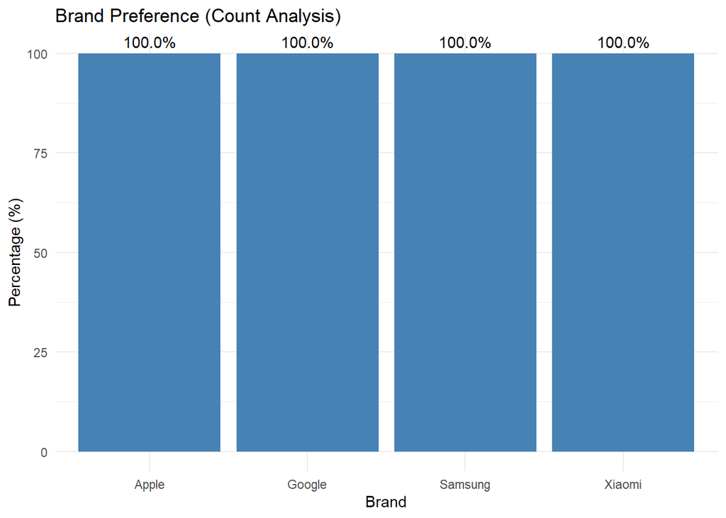

```r
counts <- conjoint_data_long %>%
  filter(choice == 1) %>%
  group_by(brand) %>%
  summarize(count = n(), percentage = count / sum(count) * 100, .groups = "drop")
ggplot(counts, aes(x = reorder(brand, -percentage), y = percentage)) +
  geom_bar(stat = "identity", fill = "steelblue") +
  geom_text(aes(label = sprintf("%.1f%%", percentage)), vjust = -0.5) +
  labs(title = "Brand Preference (Count Analysis)", x = "Brand", y = "Percentage (%)") +
  theme_minimal()
```